# Exercises: Hyperparametertuning with mlr3mbo

## Formulating the Objective

Write a function that calculates the accuracy for a given hyperparameter setting.

- Define the resampling strategy. e.g. 10-fold CV.
- Define the *accuracy* measure.
- Calculate the average error by evaluating `resample()`.
- Return the averaged accuracy by calling `$aggregate()` on the `ResampleResult`.

```r
library(mlr3)
library(mlr3learners)
library(mlr3misc)
library(data.table)
set.seed(3)

task = tsk("pima")
learner = lrn("classif.rpart")

tune_fun = function(xs) {
  this_learner = learner$clone(deep = TRUE)
  this_learner$param_set$values = insert_named(learner$param_set$values, xs)
  resampling = rsmp("cv") #!
  measure = msr("classif.acc") #!
  res = resample(task, this_learner, resampling) #!
  res = res$aggregate(measures = measure) #!
  return(list(y=res))
}
```

If you defined the function correctly this should work.

```r
tune_fun(list(cp = 0.02, minsplit = 3))
```

```
## INFO  [14:15:14.879] Applying learner 'classif.rpart' on task 'pima' (iter 1/10)
## INFO  [14:15:14.921] Applying learner 'classif.rpart' on task 'pima' (iter 2/10)
## INFO  [14:15:14.943] Applying learner 'classif.rpart' on task 'pima' (iter 3/10)
## INFO  [14:15:14.955] Applying learner 'classif.rpart' on task 'pima' (iter 4/10)
## INFO  [14:15:14.968] Applying learner 'classif.rpart' on task 'pima' (iter 5/10)
## INFO  [14:15:14.980] Applying learner 'classif.rpart' on task 'pima' (iter 6/10)
## INFO  [14:15:14.992] Applying learner 'classif.rpart' on task 'pima' (iter 7/10)
## INFO  [14:15:15.005] Applying learner 'classif.rpart' on task 'pima' (iter 8/10)
## INFO  [14:15:15.020] Applying learner 'classif.rpart' on task 'pima' (iter 9/10)
## INFO  [14:15:15.033] Applying learner 'classif.rpart' on task 'pima' (iter 10/10)
```

```
## $y
## classif.acc
##   0.7552973
```

Define the search space for this problem.

- `cp` as a real-valued parameter from 0.001 to 0.1
- `minsplit` as an integer parameter from 1 to 10

```r
library(paradox)
search_space = ParamSet$new(list(
  ParamDbl$new("cp", lower = 0.001, upper = 0.1), #!
  ParamInt$new("minsplit", lower = 1, upper = 10) #!
))
```

## Create a bbotk Objective

For optimization with `mlr3mbo` we need to wrap the function inside an `Objective` object.

- Create a codomain `ParamSet` object that contains one real-valued parameter `y` with the tag `maximize`
- Use `ObjectiveRFun$new()` to create a new `Objective` object.

```r
library(bbotk)
codomain = ParamSet$new(list(ParamDbl$new("y", tags = "maximize"))) #!
tune_obj = ObjectiveRFun$new(fun = tune_fun, domain = search_space, codomain = codomain) #!(

tune_obj$eval(list(cp = 0.02, minsplit = 3))
```

```
## INFO  [14:15:15.122] Applying learner 'classif.rpart' on task 'pima' (iter 1/10)
## INFO  [14:15:15.136] Applying learner 'classif.rpart' on task 'pima' (iter 2/10)
## INFO  [14:15:15.149] Applying learner 'classif.rpart' on task 'pima' (iter 3/10)
## INFO  [14:15:15.165] Applying learner 'classif.rpart' on task 'pima' (iter 4/10)
## INFO  [14:15:15.177] Applying learner 'classif.rpart' on task 'pima' (iter 5/10)
## INFO  [14:15:15.190] Applying learner 'classif.rpart' on task 'pima' (iter 6/10)
## INFO  [14:15:15.202] Applying learner 'classif.rpart' on task 'pima' (iter 7/10)
## INFO  [14:15:15.215] Applying learner 'classif.rpart' on task 'pima' (iter 8/10)
## INFO  [14:15:15.234] Applying learner 'classif.rpart' on task 'pima' (iter 9/10)
## INFO  [14:15:15.251] Applying learner 'classif.rpart' on task 'pima' (iter 10/10)
```

```
## $y
## classif.acc
##   0.7760424
```

- Create a `data.table` with different values for `cp` and `minsplit` and evaluate it using `tune_obj$eval_dt()`.

```r
grid = expand.grid(cp = c(0.02, 0.05, 0.09), minsplit = c(1,5,7)) #!=
tune_obj$eval_dt(grid)
```

```
## INFO  [14:15:15.306] Applying learner 'classif.rpart' on task 'pima' (iter 1/10)
## INFO  [14:15:15.319] Applying learner 'classif.rpart' on task 'pima' (iter 2/10)
## INFO  [14:15:15.333] Applying learner 'classif.rpart' on task 'pima' (iter 3/10)
## INFO  [14:15:15.346] Applying learner 'classif.rpart' on task 'pima' (iter 4/10)
## INFO  [14:15:15.361] Applying learner 'classif.rpart' on task 'pima' (iter 5/10)
## INFO  [14:15:15.374] Applying learner 'classif.rpart' on task 'pima' (iter 6/10)
## INFO  [14:15:15.387] Applying learner 'classif.rpart' on task 'pima' (iter 7/10)
## INFO  [14:15:15.399] Applying learner 'classif.rpart' on task 'pima' (iter 8/10)
## INFO  [14:15:15.410] Applying learner 'classif.rpart' on task 'pima' (iter 9/10)
## INFO  [14:15:15.425] Applying learner 'classif.rpart' on task 'pima' (iter 10/10)
## INFO  [14:15:15.460] Applying learner 'classif.rpart' on task 'pima' (iter 1/10)
## INFO  [14:15:15.474] Applying learner 'classif.rpart' on task 'pima' (iter 2/10)
## INFO  [14:15:15.486] Applying learner 'classif.rpart' on task 'pima' (iter 3/10)
## INFO  [14:15:15.498] Applying learner 'classif.rpart' on task 'pima' (iter 4/10)
## INFO  [14:15:15.509] Applying learner 'classif.rpart' on task 'pima' (iter 5/10)
## INFO  [14:15:15.520] Applying learner 'classif.rpart' on task 'pima' (iter 6/10)
## INFO  [14:15:15.535] Applying learner 'classif.rpart' on task 'pima' (iter 7/10)
## INFO  [14:15:15.547] Applying learner 'classif.rpart' on task 'pima' (iter 8/10)
## INFO  [14:15:15.559] Applying learner 'classif.rpart' on task 'pima' (iter 9/10)
## INFO  [14:15:15.570] Applying learner 'classif.rpart' on task 'pima' (iter 10/10)
## INFO  [14:15:15.607] Applying learner 'classif.rpart' on task 'pima' (iter 1/10)
## INFO  [14:15:15.618] Applying learner 'classif.rpart' on task 'pima' (iter 2/10)
## INFO  [14:15:15.632] Applying learner 'classif.rpart' on task 'pima' (iter 3/10)
## INFO  [14:15:15.644] Applying learner 'classif.rpart' on task 'pima' (iter 4/10)
## INFO  [14:15:15.655] Applying learner 'classif.rpart' on task 'pima' (iter 5/10)
## INFO  [14:15:15.666] Applying learner 'classif.rpart' on task 'pima' (iter 6/10)
## INFO  [14:15:15.678] Applying learner 'classif.rpart' on task 'pima' (iter 7/10)
## INFO  [14:15:15.711] Applying learner 'classif.rpart' on task 'pima' (iter 8/10)
## INFO  [14:15:15.725] Applying learner 'classif.rpart' on task 'pima' (iter 9/10)
## INFO  [14:15:15.738] Applying learner 'classif.rpart' on task 'pima' (iter 10/10)
## INFO  [14:15:15.779] Applying learner 'classif.rpart' on task 'pima' (iter 1/10)
## INFO  [14:15:15.791] Applying learner 'classif.rpart' on task 'pima' (iter 2/10)
## INFO  [14:15:15.803] Applying learner 'classif.rpart' on task 'pima' (iter 3/10)
## INFO  [14:15:15.814] Applying learner 'classif.rpart' on task 'pima' (iter 4/10)
## INFO  [14:15:15.829] Applying learner 'classif.rpart' on task 'pima' (iter 5/10)
## INFO  [14:15:15.843] Applying learner 'classif.rpart' on task 'pima' (iter 6/10)
## INFO  [14:15:15.855] Applying learner 'classif.rpart' on task 'pima' (iter 7/10)
## INFO  [14:15:15.866] Applying learner 'classif.rpart' on task 'pima' (iter 8/10)
## INFO  [14:15:15.879] Applying learner 'classif.rpart' on task 'pima' (iter 9/10)
## INFO  [14:15:15.893] Applying learner 'classif.rpart' on task 'pima' (iter 10/10)
```

[output cut: 35 more lines]

```
## INFO  [14:15:16.446] Applying learner 'classif.rpart' on task 'pima' (iter 6/10)
## INFO  [14:15:16.460] Applying learner 'classif.rpart' on task 'pima' (iter 7/10)
## INFO  [14:15:16.473] Applying learner 'classif.rpart' on task 'pima' (iter 8/10)
## INFO  [14:15:16.485] Applying learner 'classif.rpart' on task 'pima' (iter 9/10)
## INFO  [14:15:16.497] Applying learner 'classif.rpart' on task 'pima' (iter 10/10)
## INFO  [14:15:16.536] Applying learner 'classif.rpart' on task 'pima' (iter 1/10)
## INFO  [14:15:16.547] Applying learner 'classif.rpart' on task 'pima' (iter 2/10)
## INFO  [14:15:16.558] Applying learner 'classif.rpart' on task 'pima' (iter 3/10)
## INFO  [14:15:16.573] Applying learner 'classif.rpart' on task 'pima' (iter 4/10)
## INFO  [14:15:16.586] Applying learner 'classif.rpart' on task 'pima' (iter 5/10)
## INFO  [14:15:16.597] Applying learner 'classif.rpart' on task 'pima' (iter 6/10)
## INFO  [14:15:16.608] Applying learner 'classif.rpart' on task 'pima' (iter 7/10)
## INFO  [14:15:16.622] Applying learner 'classif.rpart' on task 'pima' (iter 8/10)
## INFO  [14:15:16.635] Applying learner 'classif.rpart' on task 'pima' (iter 9/10)
## INFO  [14:15:16.647] Applying learner 'classif.rpart' on task 'pima' (iter 10/10)
```

```
##            y
##        <num>
## 1: 0.7565619
## 2: 0.7435748
## 3: 0.7200615
## 4: 0.7605434
## 5: 0.7630725
## 6: 0.7303999
## 7: 0.7396275
## 8: 0.7524949
## 9: 0.7227102
```

## Using the bbotk Instance and Archive

How much budget do we allow for the optimization?

- Create a `Terminator` object with `n_evals = 10`.

```r
term = trm("evals", n_evals = 10) #!=
```

- Create a new `OptimInstanceSingleCrit` that contains `tune_obj` as objective and the terminator form above.
- Evaluate the grid on the instance by calling the `$eval_batch` method from the instance object.

```r
inst = OptimInstanceSingleCrit$new(objective = tune_obj, terminator = term)
inst$eval_batch(as.data.table(grid)) #!
```

```
## INFO  [14:15:16.702] Evaluating 9 configuration(s)
## INFO  [14:15:16.720] Applying learner 'classif.rpart' on task 'pima' (iter 1/10)
## INFO  [14:15:16.738] Applying learner 'classif.rpart' on task 'pima' (iter 2/10)
## INFO  [14:15:16.752] Applying learner 'classif.rpart' on task 'pima' (iter 3/10)
## INFO  [14:15:16.764] Applying learner 'classif.rpart' on task 'pima' (iter 4/10)
## INFO  [14:15:16.787] Applying learner 'classif.rpart' on task 'pima' (iter 5/10)
## INFO  [14:15:16.803] Applying learner 'classif.rpart' on task 'pima' (iter 6/10)
## INFO  [14:15:16.817] Applying learner 'classif.rpart' on task 'pima' (iter 7/10)
## INFO  [14:15:16.830] Applying learner 'classif.rpart' on task 'pima' (iter 8/10)
## INFO  [14:15:16.844] Applying learner 'classif.rpart' on task 'pima' (iter 9/10)
## INFO  [14:15:16.859] Applying learner 'classif.rpart' on task 'pima' (iter 10/10)
## INFO  [14:15:16.900] Applying learner 'classif.rpart' on task 'pima' (iter 1/10)
## INFO  [14:15:16.912] Applying learner 'classif.rpart' on task 'pima' (iter 2/10)
## INFO  [14:15:16.924] Applying learner 'classif.rpart' on task 'pima' (iter 3/10)
## INFO  [14:15:16.935] Applying learner 'classif.rpart' on task 'pima' (iter 4/10)
## INFO  [14:15:16.953] Applying learner 'classif.rpart' on task 'pima' (iter 5/10)
## INFO  [14:15:16.965] Applying learner 'classif.rpart' on task 'pima' (iter 6/10)
## INFO  [14:15:16.977] Applying learner 'classif.rpart' on task 'pima' (iter 7/10)
## INFO  [14:15:16.989] Applying learner 'classif.rpart' on task 'pima' (iter 8/10)
## INFO  [14:15:17.004] Applying learner 'classif.rpart' on task 'pima' (iter 9/10)
## INFO  [14:15:17.016] Applying learner 'classif.rpart' on task 'pima' (iter 10/10)
## INFO  [14:15:17.058] Applying learner 'classif.rpart' on task 'pima' (iter 1/10)
## INFO  [14:15:17.069] Applying learner 'classif.rpart' on task 'pima' (iter 2/10)
## INFO  [14:15:17.081] Applying learner 'classif.rpart' on task 'pima' (iter 3/10)
## INFO  [14:15:17.097] Applying learner 'classif.rpart' on task 'pima' (iter 4/10)
## INFO  [14:15:17.110] Applying learner 'classif.rpart' on task 'pima' (iter 5/10)
## INFO  [14:15:17.121] Applying learner 'classif.rpart' on task 'pima' (iter 6/10)
## INFO  [14:15:17.133] Applying learner 'classif.rpart' on task 'pima' (iter 7/10)
## INFO  [14:15:17.148] Applying learner 'classif.rpart' on task 'pima' (iter 8/10)
## INFO  [14:15:17.160] Applying learner 'classif.rpart' on task 'pima' (iter 9/10)
## INFO  [14:15:17.172] Applying learner 'classif.rpart' on task 'pima' (iter 10/10)
## INFO  [14:15:17.211] Applying learner 'classif.rpart' on task 'pima' (iter 1/10)
## INFO  [14:15:17.223] Applying learner 'classif.rpart' on task 'pima' (iter 2/10)
## INFO  [14:15:17.240] Applying learner 'classif.rpart' on task 'pima' (iter 3/10)
## INFO  [14:15:17.253] Applying learner 'classif.rpart' on task 'pima' (iter 4/10)
## INFO  [14:15:17.265] Applying learner 'classif.rpart' on task 'pima' (iter 5/10)
## INFO  [14:15:17.282] Applying learner 'classif.rpart' on task 'pima' (iter 6/10)
## INFO  [14:15:17.297] Applying learner 'classif.rpart' on task 'pima' (iter 7/10)
## INFO  [14:15:17.310] Applying learner 'classif.rpart' on task 'pima' (iter 8/10)
## INFO  [14:15:17.322] Applying learner 'classif.rpart' on task 'pima' (iter 9/10)
```

[output cut: 47 more lines]

```
## INFO  [14:15:18.100] Applying learner 'classif.rpart' on task 'pima' (iter 7/10)
## INFO  [14:15:18.111] Applying learner 'classif.rpart' on task 'pima' (iter 8/10)
## INFO  [14:15:18.122] Applying learner 'classif.rpart' on task 'pima' (iter 9/10)
## INFO  [14:15:18.136] Applying learner 'classif.rpart' on task 'pima' (iter 10/10)
## INFO  [14:15:18.159] Result of batch 1:
## INFO  [14:15:18.160]    cp minsplit         y
## INFO  [14:15:18.160]  0.02        1 0.7448565
## INFO  [14:15:18.160]  0.05        1 0.7381408
## INFO  [14:15:18.160]  0.09        1 0.7290841
## INFO  [14:15:18.160]  0.02        5 0.7486329
## INFO  [14:15:18.160]  0.05        5 0.7421224
## INFO  [14:15:18.160]  0.09        5 0.7344498
## INFO  [14:15:18.160]  0.02        7 0.7395420
## INFO  [14:15:18.160]  0.05        7 0.7513500
## INFO  [14:15:18.160]  0.09        7 0.7202666
```

```r
inst$is_terminated
```

```
## [1] FALSE
```

```r
inst$archive$best()
```

```
##       cp minsplit       y  x_domain           timestamp batch_nr
##    <num>    <num>   <num>    <list>              <POSc>    <int>
## 1:  0.05        7 0.75135 <list[2]> 2020-09-24 14:15:18        1
```

```r
inst$archive$n_evals # we have one more evaluation to go.
```

```
## [1] 9
```

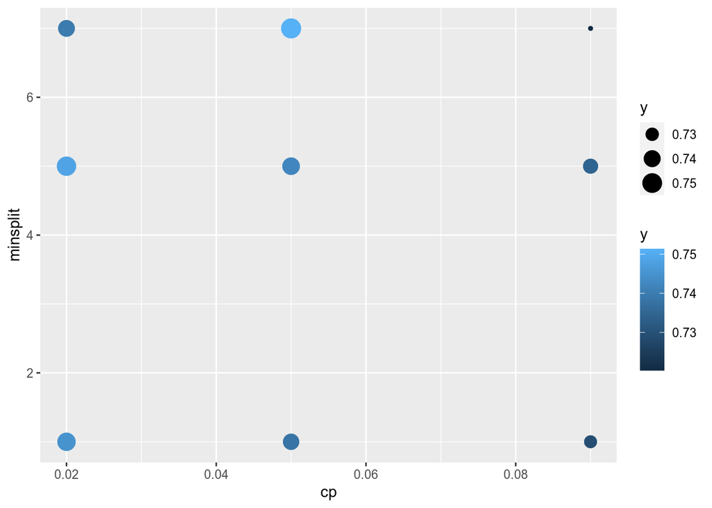

```r
archdata = inst$archive$data()
library(ggplot2)
ggplot(archdata, aes(x=cp, y=minsplit, size=y, color=y)) + geom_point()
```

- Based on the plot, try to make a good proposal what would be a good hyperparameter setting.
- Evaluate your guess using the `$eval_batch` method from the instance object.
- Could you beat the best configuration?

```r
inst$eval_batch(data.table(minsplit = 4, cp = 0.01)) #!(
```

```
## INFO  [14:15:18.714] Evaluating 1 configuration(s)
## INFO  [14:15:18.732] Applying learner 'classif.rpart' on task 'pima' (iter 1/10)
## INFO  [14:15:18.745] Applying learner 'classif.rpart' on task 'pima' (iter 2/10)
## INFO  [14:15:18.757] Applying learner 'classif.rpart' on task 'pima' (iter 3/10)
## INFO  [14:15:18.770] Applying learner 'classif.rpart' on task 'pima' (iter 4/10)
## INFO  [14:15:18.784] Applying learner 'classif.rpart' on task 'pima' (iter 5/10)
## INFO  [14:15:18.800] Applying learner 'classif.rpart' on task 'pima' (iter 6/10)
## INFO  [14:15:18.815] Applying learner 'classif.rpart' on task 'pima' (iter 7/10)
## INFO  [14:15:18.832] Applying learner 'classif.rpart' on task 'pima' (iter 8/10)
## INFO  [14:15:18.848] Applying learner 'classif.rpart' on task 'pima' (iter 9/10)
## INFO  [14:15:18.868] Applying learner 'classif.rpart' on task 'pima' (iter 10/10)
## INFO  [14:15:18.898] Result of batch 2:
## INFO  [14:15:18.899]  minsplit   cp         y
## INFO  [14:15:18.899]         4 0.01 0.7578093
```

```r
max(inst$archive$data()$y[1:9]) < inst$archive$data()$y[10]
```

```
## [1] TRUE
```

You probably noticed that the instance prevents evaluations above the budget.

```r
inst$eval_batch(data.table(minsplit = 7, cp = 0.01)) #terminated error is expected!
```

```
## Error: Objective (obj:function, term:<TerminatorEvals>) terminated
```

# mlr3mbo

## Components

For MBO we need to define the *Surrogate*, the *Acquistion Function* and an *Optimizer* for the Acquistion Function.

- Choose a regression learner for the surrogate model, e.g. `regr.km`.
- Set the iteration number of the `acq_optimizer` to 1100.

```r
library(mlr3mbo)
surrogate = SurrogateSingleCritLearner$new(learner = lrn("regr.km", nugget.estim = TRUE, covtype = "matern3_2")) #!lrn(
surrogate$model$encapsulate = c(train = "callr", predict = "none") # prevents output from regr.km learner
acq_function = AcqFunctionCB$new(surrogate)
acq_optimizer = AcqOptimizerRandomSearch$new()
acq_optimizer$param_set$values$iters = 1100 #!$iters
```

## Preparing the loop

MBO can only start with some points that are already evaluated.

- Populate the instance with 10 random points by calling `$eval_batch()`

```r
instance = OptimInstanceSingleCrit$new(
  objective = tune_obj,
  terminator = trm("evals", n_evals = 15)
)
design = generate_design_lhs(search_space, 10)$data
instance$eval_batch(design) #!
```

```
## INFO  [14:15:19.082] Evaluating 10 configuration(s)
## INFO  [14:15:19.100] Applying learner 'classif.rpart' on task 'pima' (iter 1/10)
## INFO  [14:15:19.112] Applying learner 'classif.rpart' on task 'pima' (iter 2/10)
## INFO  [14:15:19.123] Applying learner 'classif.rpart' on task 'pima' (iter 3/10)
## INFO  [14:15:19.139] Applying learner 'classif.rpart' on task 'pima' (iter 4/10)
## INFO  [14:15:19.151] Applying learner 'classif.rpart' on task 'pima' (iter 5/10)
## INFO  [14:15:19.163] Applying learner 'classif.rpart' on task 'pima' (iter 6/10)
## INFO  [14:15:19.175] Applying learner 'classif.rpart' on task 'pima' (iter 7/10)
## INFO  [14:15:19.187] Applying learner 'classif.rpart' on task 'pima' (iter 8/10)
## INFO  [14:15:19.199] Applying learner 'classif.rpart' on task 'pima' (iter 9/10)
## INFO  [14:15:19.211] Applying learner 'classif.rpart' on task 'pima' (iter 10/10)
## INFO  [14:15:19.249] Applying learner 'classif.rpart' on task 'pima' (iter 1/10)
## INFO  [14:15:19.262] Applying learner 'classif.rpart' on task 'pima' (iter 2/10)
## INFO  [14:15:19.275] Applying learner 'classif.rpart' on task 'pima' (iter 3/10)
## INFO  [14:15:19.287] Applying learner 'classif.rpart' on task 'pima' (iter 4/10)
## INFO  [14:15:19.299] Applying learner 'classif.rpart' on task 'pima' (iter 5/10)
## INFO  [14:15:19.311] Applying learner 'classif.rpart' on task 'pima' (iter 6/10)
## INFO  [14:15:19.323] Applying learner 'classif.rpart' on task 'pima' (iter 7/10)
## INFO  [14:15:19.335] Applying learner 'classif.rpart' on task 'pima' (iter 8/10)
## INFO  [14:15:19.348] Applying learner 'classif.rpart' on task 'pima' (iter 9/10)
## INFO  [14:15:19.392] Applying learner 'classif.rpart' on task 'pima' (iter 10/10)
## INFO  [14:15:19.431] Applying learner 'classif.rpart' on task 'pima' (iter 1/10)
## INFO  [14:15:19.444] Applying learner 'classif.rpart' on task 'pima' (iter 2/10)
## INFO  [14:15:19.456] Applying learner 'classif.rpart' on task 'pima' (iter 3/10)
## INFO  [14:15:19.468] Applying learner 'classif.rpart' on task 'pima' (iter 4/10)
## INFO  [14:15:19.480] Applying learner 'classif.rpart' on task 'pima' (iter 5/10)
## INFO  [14:15:19.492] Applying learner 'classif.rpart' on task 'pima' (iter 6/10)
## INFO  [14:15:19.509] Applying learner 'classif.rpart' on task 'pima' (iter 7/10)
## INFO  [14:15:19.523] Applying learner 'classif.rpart' on task 'pima' (iter 8/10)
## INFO  [14:15:19.535] Applying learner 'classif.rpart' on task 'pima' (iter 9/10)
## INFO  [14:15:19.546] Applying learner 'classif.rpart' on task 'pima' (iter 10/10)
## INFO  [14:15:19.580] Applying learner 'classif.rpart' on task 'pima' (iter 1/10)
## INFO  [14:15:19.591] Applying learner 'classif.rpart' on task 'pima' (iter 2/10)
## INFO  [14:15:19.603] Applying learner 'classif.rpart' on task 'pima' (iter 3/10)
## INFO  [14:15:19.613] Applying learner 'classif.rpart' on task 'pima' (iter 4/10)
## INFO  [14:15:19.629] Applying learner 'classif.rpart' on task 'pima' (iter 5/10)
## INFO  [14:15:19.641] Applying learner 'classif.rpart' on task 'pima' (iter 6/10)
## INFO  [14:15:19.653] Applying learner 'classif.rpart' on task 'pima' (iter 7/10)
## INFO  [14:15:19.665] Applying learner 'classif.rpart' on task 'pima' (iter 8/10)
## INFO  [14:15:19.676] Applying learner 'classif.rpart' on task 'pima' (iter 9/10)
```

[output cut: 58 more lines]

```
## INFO  [14:15:20.549] Applying learner 'classif.rpart' on task 'pima' (iter 8/10)
## INFO  [14:15:20.562] Applying learner 'classif.rpart' on task 'pima' (iter 9/10)
## INFO  [14:15:20.574] Applying learner 'classif.rpart' on task 'pima' (iter 10/10)
## INFO  [14:15:20.596] Result of batch 1:
## INFO  [14:15:20.597]           cp minsplit         y
## INFO  [14:15:20.597]  0.046389848        9 0.7344156
## INFO  [14:15:20.597]  0.084580167        4 0.7057587
## INFO  [14:15:20.597]  0.075247604        6 0.7369788
## INFO  [14:15:20.597]  0.035336940        5 0.7501196
## INFO  [14:15:20.597]  0.059328565        1 0.7382433
## INFO  [14:15:20.597]  0.002045486        2 0.7057075
## INFO  [14:15:20.597]  0.096358302        8 0.7317840
## INFO  [14:15:20.597]  0.014990095        7 0.7643882
## INFO  [14:15:20.597]  0.025140751       10 0.7356630
## INFO  [14:15:20.597]  0.062680196        3 0.7265721
```

The following code generates one proposal and evaluates it on the objective.

```r
# only needs to be run once at the beginning
archive = instance$archive # reference
acq_function$setup(archive) #

# the steps we need to repeat
xydt = archive$data()
surrogate$update(xydt = xydt[, c(archive$cols_x, archive$cols_y), with = FALSE], y_cols = archive$cols_y) #update surrogate model with new data
acq_function$update(archive)
```

```r
xdt = acq_optimizer$optimize(acq_function)
instance$eval_batch(xdt)
```

```
## INFO  [14:15:21.273] Evaluating 1 configuration(s)
## INFO  [14:15:21.292] Applying learner 'classif.rpart' on task 'pima' (iter 1/10)
## INFO  [14:15:21.306] Applying learner 'classif.rpart' on task 'pima' (iter 2/10)
## INFO  [14:15:21.324] Applying learner 'classif.rpart' on task 'pima' (iter 3/10)
## INFO  [14:15:21.337] Applying learner 'classif.rpart' on task 'pima' (iter 4/10)
## INFO  [14:15:21.349] Applying learner 'classif.rpart' on task 'pima' (iter 5/10)
## INFO  [14:15:21.361] Applying learner 'classif.rpart' on task 'pima' (iter 6/10)
## INFO  [14:15:21.373] Applying learner 'classif.rpart' on task 'pima' (iter 7/10)
## INFO  [14:15:21.386] Applying learner 'classif.rpart' on task 'pima' (iter 8/10)
## INFO  [14:15:21.399] Applying learner 'classif.rpart' on task 'pima' (iter 9/10)
## INFO  [14:15:21.415] Applying learner 'classif.rpart' on task 'pima' (iter 10/10)
## INFO  [14:15:21.437] Result of batch 2:
## INFO  [14:15:21.438]         cp minsplit         y
## INFO  [14:15:21.438]  0.0862587        9 0.7460355
```

- Transform the code from above into a loop that proposes points, evaluates them on the objective and updates the surrogate.

```r
repeat {
  xydt = archive$data()
  surrogate$update(xydt = xydt[, c(archive$cols_x, archive$cols_y), with = FALSE], y_cols = archive$cols_y) #update surrogate model with new data
  acq_function$update(archive)
  xdt = acq_optimizer$optimize(acq_function)
  instance$eval_batch(xdt)
  if (instance$is_terminated || instance$terminator$is_terminated(archive)) break
}
```

```
## INFO  [14:15:22.041] Evaluating 1 configuration(s)
## INFO  [14:15:22.061] Applying learner 'classif.rpart' on task 'pima' (iter 1/10)
## INFO  [14:15:22.074] Applying learner 'classif.rpart' on task 'pima' (iter 2/10)
## INFO  [14:15:22.085] Applying learner 'classif.rpart' on task 'pima' (iter 3/10)
## INFO  [14:15:22.097] Applying learner 'classif.rpart' on task 'pima' (iter 4/10)
## INFO  [14:15:22.108] Applying learner 'classif.rpart' on task 'pima' (iter 5/10)
## INFO  [14:15:22.124] Applying learner 'classif.rpart' on task 'pima' (iter 6/10)
## INFO  [14:15:22.135] Applying learner 'classif.rpart' on task 'pima' (iter 7/10)
## INFO  [14:15:22.147] Applying learner 'classif.rpart' on task 'pima' (iter 8/10)
## INFO  [14:15:22.158] Applying learner 'classif.rpart' on task 'pima' (iter 9/10)
## INFO  [14:15:22.170] Applying learner 'classif.rpart' on task 'pima' (iter 10/10)
## INFO  [14:15:22.191] Result of batch 3:
## INFO  [14:15:22.192]          cp minsplit         y
## INFO  [14:15:22.192]  0.07593076        7 0.7423616
## INFO  [14:15:22.774] Evaluating 1 configuration(s)
## INFO  [14:15:22.795] Applying learner 'classif.rpart' on task 'pima' (iter 1/10)
## INFO  [14:15:22.809] Applying learner 'classif.rpart' on task 'pima' (iter 2/10)
## INFO  [14:15:22.825] Applying learner 'classif.rpart' on task 'pima' (iter 3/10)
## INFO  [14:15:22.837] Applying learner 'classif.rpart' on task 'pima' (iter 4/10)
## INFO  [14:15:22.848] Applying learner 'classif.rpart' on task 'pima' (iter 5/10)
## INFO  [14:15:22.860] Applying learner 'classif.rpart' on task 'pima' (iter 6/10)
## INFO  [14:15:22.872] Applying learner 'classif.rpart' on task 'pima' (iter 7/10)
## INFO  [14:15:22.884] Applying learner 'classif.rpart' on task 'pima' (iter 8/10)
## INFO  [14:15:22.896] Applying learner 'classif.rpart' on task 'pima' (iter 9/10)
## INFO  [14:15:22.912] Applying learner 'classif.rpart' on task 'pima' (iter 10/10)
## INFO  [14:15:22.932] Result of batch 4:
## INFO  [14:15:22.934]         cp minsplit         y
## INFO  [14:15:22.934]  0.0277315        7 0.7566815
## INFO  [14:15:23.513] Evaluating 1 configuration(s)
## INFO  [14:15:23.533] Applying learner 'classif.rpart' on task 'pima' (iter 1/10)
## INFO  [14:15:23.548] Applying learner 'classif.rpart' on task 'pima' (iter 2/10)
## INFO  [14:15:23.561] Applying learner 'classif.rpart' on task 'pima' (iter 3/10)
## INFO  [14:15:23.574] Applying learner 'classif.rpart' on task 'pima' (iter 4/10)
## INFO  [14:15:23.586] Applying learner 'classif.rpart' on task 'pima' (iter 5/10)
## INFO  [14:15:23.603] Applying learner 'classif.rpart' on task 'pima' (iter 6/10)
## INFO  [14:15:23.616] Applying learner 'classif.rpart' on task 'pima' (iter 7/10)
## INFO  [14:15:23.629] Applying learner 'classif.rpart' on task 'pima' (iter 8/10)
## INFO  [14:15:23.642] Applying learner 'classif.rpart' on task 'pima' (iter 9/10)
## INFO  [14:15:23.654] Applying learner 'classif.rpart' on task 'pima' (iter 10/10)
## INFO  [14:15:23.702] Result of batch 5:
## INFO  [14:15:23.704]           cp minsplit         y
## INFO  [14:15:23.704]  0.001571398        7 0.7304511
## INFO  [14:15:24.293] Evaluating 1 configuration(s)
## INFO  [14:15:24.314] Applying learner 'classif.rpart' on task 'pima' (iter 1/10)
## INFO  [14:15:24.327] Applying learner 'classif.rpart' on task 'pima' (iter 2/10)
## INFO  [14:15:24.348] Applying learner 'classif.rpart' on task 'pima' (iter 3/10)
## INFO  [14:15:24.361] Applying learner 'classif.rpart' on task 'pima' (iter 4/10)
## INFO  [14:15:24.374] Applying learner 'classif.rpart' on task 'pima' (iter 5/10)
## INFO  [14:15:24.386] Applying learner 'classif.rpart' on task 'pima' (iter 6/10)
## INFO  [14:15:24.399] Applying learner 'classif.rpart' on task 'pima' (iter 7/10)
## INFO  [14:15:24.410] Applying learner 'classif.rpart' on task 'pima' (iter 8/10)
## INFO  [14:15:24.422] Applying learner 'classif.rpart' on task 'pima' (iter 9/10)
## INFO  [14:15:24.437] Applying learner 'classif.rpart' on task 'pima' (iter 10/10)
## INFO  [14:15:24.462] Result of batch 6:
## INFO  [14:15:24.464]          cp minsplit        y
## INFO  [14:15:24.464]  0.01981058        6 0.745933
```

We can visualize the *acquistion function*.

```r
# first we update it with the latest evaluation
xydt = archive$data()
surrogate$update(xydt = xydt[, c(archive$cols_x, archive$cols_y), with = FALSE], y_cols = archive$cols_y) #update surrogate model with new data
acq_function$update(archive)
```

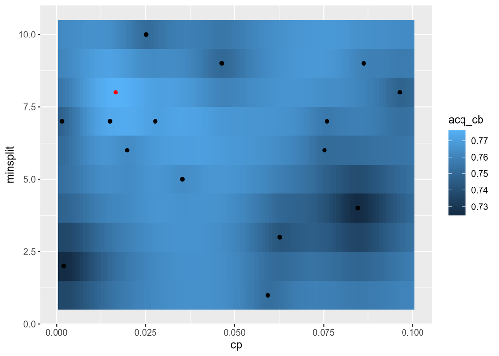

```r
xdt = acq_optimizer$optimize(acq_function)

fine_grid = generate_design_grid(search_space, resolution = 100)$data
res = acq_function$eval_dt(fine_grid)
fine_grid = cbind(fine_grid, res)
g = ggplot(fine_grid, aes(x=cp, y=minsplit)) + geom_raster(aes(fill=acq_cb))
g = g + geom_point(data = instance$archive$data())
g = g + geom_point(data = acq_optimizer$optimize(acq_function), col = "red")
g
```

We can also visualize the *Surrogate*.

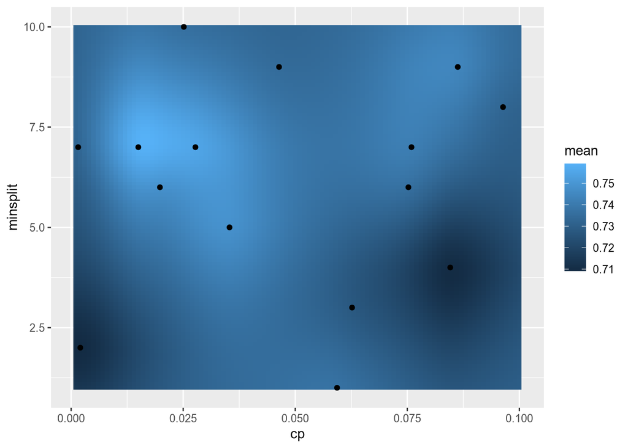

```r
search_space_dbl = ParamSet$new(list(
  ParamDbl$new("cp", lower = 0.001, upper = 0.1), #!
  ParamDbl$new("minsplit", lower = 1, upper = 10) #!
))
fine_grid = generate_design_grid(search_space_dbl, resolution = 100)$data
res = surrogate$predict(xdt = fine_grid)
fine_grid = cbind(fine_grid, res)
g = ggplot(fine_grid, aes(x=cp, y=minsplit)) + geom_raster(aes(fill=mean))
g = g + geom_point(data = instance$archive$data())
g
```

# mlr3mbo multiple proposals

First, we create a new `OptimInstanceSingleCrit` and all MBO components that we need. Exactly as before, nothing has to be modified here.

```r
# tuning instance
tune_fun = function(xs, task = tsk("pima"), learner = lrn("classif.rpart")) {
  this_learner = learner$clone(deep = TRUE)
  this_learner$param_set$values = insert_named(learner$param_set$values, xs)
  res = resample(task, this_learner, rsmp("cv"))
  res = res$aggregate(msr("classif.acc"))
  return(list(y=res))
}

search_space = ParamSet$new(list(
  ParamDbl$new("cp", lower = 0.001, upper = 0.1),
  ParamInt$new("minsplit", lower = 1, upper = 10)
))

codomain = ParamSet$new(list(ParamDbl$new("y", tags = "maximize")))
tune_obj = ObjectiveRFun$new(fun = tune_fun, domain = search_space, codomain = codomain)

instance = OptimInstanceSingleCrit$new(
  objective = tune_obj,
  terminator = trm("evals", n_evals = 20)
)
design = generate_design_lhs(search_space, 10)$data
instance$eval_batch(design)
```

```
## INFO  [14:15:25.741] Evaluating 10 configuration(s)
## INFO  [14:15:25.785] Applying learner 'classif.rpart' on task 'pima' (iter 1/10)
## INFO  [14:15:25.807] Applying learner 'classif.rpart' on task 'pima' (iter 2/10)
## INFO  [14:15:25.824] Applying learner 'classif.rpart' on task 'pima' (iter 3/10)
## INFO  [14:15:25.840] Applying learner 'classif.rpart' on task 'pima' (iter 4/10)
## INFO  [14:15:25.855] Applying learner 'classif.rpart' on task 'pima' (iter 5/10)
## INFO  [14:15:25.871] Applying learner 'classif.rpart' on task 'pima' (iter 6/10)
## INFO  [14:15:25.885] Applying learner 'classif.rpart' on task 'pima' (iter 7/10)
## INFO  [14:15:25.898] Applying learner 'classif.rpart' on task 'pima' (iter 8/10)
## INFO  [14:15:25.916] Applying learner 'classif.rpart' on task 'pima' (iter 9/10)
## INFO  [14:15:25.933] Applying learner 'classif.rpart' on task 'pima' (iter 10/10)
## INFO  [14:15:26.011] Applying learner 'classif.rpart' on task 'pima' (iter 1/10)
## INFO  [14:15:26.030] Applying learner 'classif.rpart' on task 'pima' (iter 2/10)
## INFO  [14:15:26.047] Applying learner 'classif.rpart' on task 'pima' (iter 3/10)
## INFO  [14:15:26.064] Applying learner 'classif.rpart' on task 'pima' (iter 4/10)
## INFO  [14:15:26.080] Applying learner 'classif.rpart' on task 'pima' (iter 5/10)
## INFO  [14:15:26.098] Applying learner 'classif.rpart' on task 'pima' (iter 6/10)
## INFO  [14:15:26.114] Applying learner 'classif.rpart' on task 'pima' (iter 7/10)
## INFO  [14:15:26.136] Applying learner 'classif.rpart' on task 'pima' (iter 8/10)
## INFO  [14:15:26.155] Applying learner 'classif.rpart' on task 'pima' (iter 9/10)
## INFO  [14:15:26.172] Applying learner 'classif.rpart' on task 'pima' (iter 10/10)
## INFO  [14:15:26.237] Applying learner 'classif.rpart' on task 'pima' (iter 1/10)
## INFO  [14:15:26.252] Applying learner 'classif.rpart' on task 'pima' (iter 2/10)
## INFO  [14:15:26.265] Applying learner 'classif.rpart' on task 'pima' (iter 3/10)
## INFO  [14:15:26.277] Applying learner 'classif.rpart' on task 'pima' (iter 4/10)
## INFO  [14:15:26.290] Applying learner 'classif.rpart' on task 'pima' (iter 5/10)
## INFO  [14:15:26.303] Applying learner 'classif.rpart' on task 'pima' (iter 6/10)
## INFO  [14:15:26.315] Applying learner 'classif.rpart' on task 'pima' (iter 7/10)
## INFO  [14:15:26.332] Applying learner 'classif.rpart' on task 'pima' (iter 8/10)
## INFO  [14:15:26.347] Applying learner 'classif.rpart' on task 'pima' (iter 9/10)
## INFO  [14:15:26.360] Applying learner 'classif.rpart' on task 'pima' (iter 10/10)
## INFO  [14:15:26.418] Applying learner 'classif.rpart' on task 'pima' (iter 1/10)
## INFO  [14:15:26.431] Applying learner 'classif.rpart' on task 'pima' (iter 2/10)
## INFO  [14:15:26.443] Applying learner 'classif.rpart' on task 'pima' (iter 3/10)
## INFO  [14:15:26.454] Applying learner 'classif.rpart' on task 'pima' (iter 4/10)
## INFO  [14:15:26.466] Applying learner 'classif.rpart' on task 'pima' (iter 5/10)
## INFO  [14:15:26.478] Applying learner 'classif.rpart' on task 'pima' (iter 6/10)
## INFO  [14:15:26.494] Applying learner 'classif.rpart' on task 'pima' (iter 7/10)
## INFO  [14:15:26.509] Applying learner 'classif.rpart' on task 'pima' (iter 8/10)
## INFO  [14:15:26.523] Applying learner 'classif.rpart' on task 'pima' (iter 9/10)
```

[output cut: 58 more lines]

```
## INFO  [14:15:27.598] Applying learner 'classif.rpart' on task 'pima' (iter 8/10)
## INFO  [14:15:27.611] Applying learner 'classif.rpart' on task 'pima' (iter 9/10)
## INFO  [14:15:27.622] Applying learner 'classif.rpart' on task 'pima' (iter 10/10)
## INFO  [14:15:27.654] Result of batch 1:
## INFO  [14:15:27.656]           cp minsplit         y
## INFO  [14:15:27.656]  0.086793427        7 0.7408578
## INFO  [14:15:27.656]  0.007273131        4 0.7434211
## INFO  [14:15:27.656]  0.058855209        5 0.7446856
## INFO  [14:15:27.656]  0.046906077        8 0.7420882
## INFO  [14:15:27.656]  0.060572900        2 0.7538961
## INFO  [14:15:27.656]  0.031312185       10 0.7434894
## INFO  [14:15:27.656]  0.014345929        1 0.7526316
## INFO  [14:15:27.656]  0.073592097        9 0.7395762
## INFO  [14:15:27.656]  0.099311846        3 0.7278366
## INFO  [14:15:27.656]  0.030534546        6 0.7591593
```

```r
# mbo components
surrogate = SurrogateSingleCritLearner$new(learner = lrn("regr.km", nugget.estim = TRUE, covtype = "matern3_2"))
acq_function = AcqFunctionCB$new(surrogate)
acq_optimizer = AcqOptimizerRandomSearch$new()
```

Here we have the code that executes the MBO Loop.

Within the loop

- set the `lambda` value of the `cb` `acq_function` to 1
- optimize the `acq_function` and store the proposal
- set the `lambda` value of the `cb` `acq_function` to 10
- optimize the `acq_function` again and store the proposal
- `rbind` both proposals and evaluate them on the instance

```r
# only needs to be run once at the beginning
archive = instance$archive # reference
acq_function$setup(archive)

repeat {
  xydt = archive$data()
  surrogate$update(xydt = xydt[, c(archive$cols_x, archive$cols_y), with = FALSE], y_cols = archive$cols_y) #update surrogate model with new data
  acq_function$update(archive)
  acq_function$param_set$values$lambda = 1L #!
  xdt_1 = acq_optimizer$optimize(acq_function) #!
  acq_function$param_set$values$lambda = 10L #!
  xdt_10 = acq_optimizer$optimize(acq_function) #!
  xdt = rbind(xdt_1, xdt_10) #!
  instance$eval_batch(xdt)
  if (instance$is_terminated || instance$terminator$is_terminated(archive)) break
}
```

[output not shown]

[output cut: 255 more lines]

```
## INFO  [14:15:29.905] Applying learner 'classif.rpart' on task 'pima' (iter 10/10)
## INFO  [14:15:29.954] Applying learner 'classif.rpart' on task 'pima' (iter 1/10)
## INFO  [14:15:29.965] Applying learner 'classif.rpart' on task 'pima' (iter 2/10)
## INFO  [14:15:29.976] Applying learner 'classif.rpart' on task 'pima' (iter 3/10)
## INFO  [14:15:29.988] Applying learner 'classif.rpart' on task 'pima' (iter 4/10)
## INFO  [14:15:29.999] Applying learner 'classif.rpart' on task 'pima' (iter 5/10)
## INFO  [14:15:30.010] Applying learner 'classif.rpart' on task 'pima' (iter 6/10)
## INFO  [14:15:30.025] Applying learner 'classif.rpart' on task 'pima' (iter 7/10)
## INFO  [14:15:30.037] Applying learner 'classif.rpart' on task 'pima' (iter 8/10)
## INFO  [14:15:30.048] Applying learner 'classif.rpart' on task 'pima' (iter 9/10)
## INFO  [14:15:30.059] Applying learner 'classif.rpart' on task 'pima' (iter 10/10)
## INFO  [14:15:30.081] Result of batch 6:
## INFO  [14:15:30.082]          cp minsplit         y
## INFO  [14:15:30.082]  0.03477551        1 0.7578264
## INFO  [14:15:30.082]  0.04805401        1 0.7251880
```

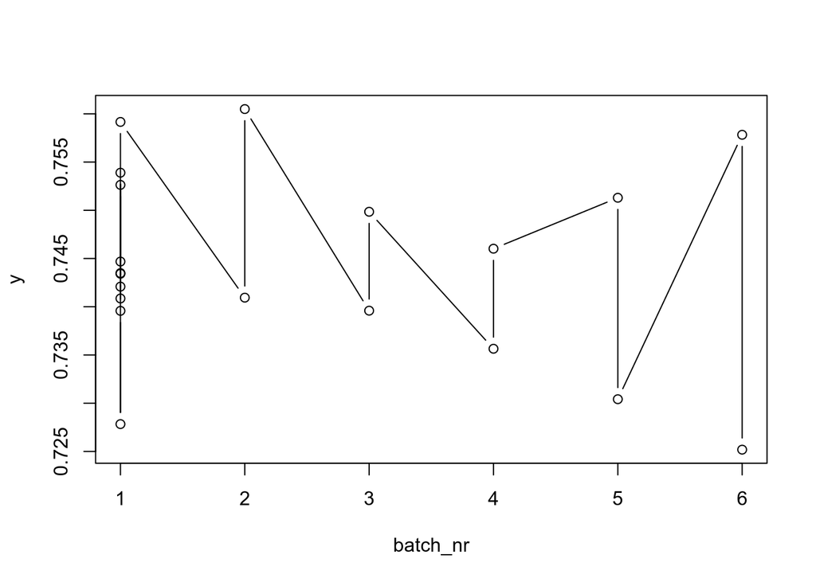

```r
opdt = instance$archive$data()
plot(y~batch_nr, data = opdt, type = "b")
```

We can see that in each iteration we evaluate two proposals. The first one belongs to the proposal made with lambda = 1.

## Results for noisy optimization functions

Instead of picking the x values that yielded the best y value we should take the noise into consideration. We can ask the surrogate for an estimation of a “noise-free” value of y.

```r
# result for noisy evals
xydt = archive$data()
surrogate$update(xydt = xydt[, c(archive$cols_x, archive$cols_y), with = FALSE], y_cols = archive$cols_y) #update surrogate model with new data
```

[output not shown]

```r
surrogate$model$param_set$values$jitter = 0.001
preds = surrogate$predict(xydt)
best = which.max(preds$mean) # compare to which.max(xydt$y)
instance$assign_result(xdt = xydt[best, archive$cols_x, with = FALSE], unlist(xydt[best, archive$cols_y, with = FALSE]))
```